# LA REVOLUCIÓN DEL BIG DATA EN EL TRANSPORTE

Yulia Frenkel

30 10 2020

```r
# Borro variables de entorno y establezco directorio de trabajo
rm(list = ls())
```

# TRABAJO PRÁCTICO

## 1.La Tarea

### 1.1. Objetivo:

El objetivo de este ejercicio es familiarizarse con la relación entre usos del suelo y transporte a través de un indicador de accesibilidad agregado. Para ello, se plantea calcular el potencial que tienen tres localizaciones para acceder a mano de obra. Por ejemplo, una gran industria puede tener como factor de localización una elevada masa de población residente lo más cerca posible. Desde el punto de vista técnico, el objetivo es dotar al estudiante de la habilidad de realizar un flujo de trabajo completo, desde la adquisición de datos, tratamiento, almacenamiento en una base de datos espacial, análisis y evaluación de resultados.

### 1.2. Enunciado:

Calcula la accesibilidad potencial que tienen tres municipios de una provincia de tu elección a mano de obra del entorno. Para ello, utiliza el indicador de potencial económico. La masa (M) será la población residente en todos los demás municipios de la provincia, puesto que el área de influencia no se limita a los tres municipios elegidos, y el coste (C) será la distancia que separa cada uno de los tres municipios de todos los demás municipios de la provincia calculada por la red de transporte.

### 1.3. Entrega:

La entrega de esta tarea constará de los siguientes documentos (comprimidos en un único fichero .zip o .7z): 1. Documento html de Rmarkdown con el código utilizado, explicación de los pasos seguidos y resultados parciales y finales más significativos. 2. Documento en pdf con un breve análisis del resultado y el planteamiento de mejoras al modelo.

### 1.4.Descripción de tareas:

El desarrollo de este caso práctico consta de las siguientes tareas: 1. Instalar PostgreSQL con las extensiones PostGIS y pgRouting y osm2po 2. Conectar a la base de datos desde R 3. Obtener la red de carreteras de la provincia elegida y zonas limítrofes (fuente recomendada OSM) 4. Obtener los polígonos de los municipios de la provincia elegida (fuente recomendada IGN) 5. Descargar los datos de población por municipio más recientes (fuente recomendada INE) 6. Calcular los centroides de los municipios utilizando funciones PostGIS desde R 7. Crear la topología de la red de carreteras utilizando funciones pgRouting desde R 8. Vincular cada centroide con la red de carreteras 9. Utilizar las funciones de cálculo de rutas de pgRouting para obtener una matriz origen‐destino 10. Calcular el potencial económico (también llamado potencial de mercado) de cada uno de los tres municipios seleccionados según la fórmula disponible en la página 49 de los apuntes (explicación en la tercera videoclase) 11. Presentar los resultados del cálculo del potencial económico de los tres municipios seleccionados en forma de tabla, gráfico o mapa, según se considere más oportuno 12. Analizar el resultado (¿qué localización elegirías para una actividad con alta demanda de mano de obra?) y plantear mejoras al modelo y fuente de los datos. Por ejemplo, ¿qué sucedería si se incrementa o disminuye el parámetro de α de decaimiento con la distancia? ¿Qué datos aportarían mayor nivel de detalle espacial/temporal? Etc.

## 2.Instalacion de las programas y los paquetes

### 2.1.Instalar PostgreSQL con las extensiones PostGIS y pgRouting y osm2po.

### 2.2.Creación de una base de datos desde pgAdmin 4.Descarga de la red de carreteras de OpenStreetMap.

### 2.3.Instalar los paquetes

- Data.table: para importar y tratar tablas
- sf: para importar y tratar datos espaciales como simple features
- RPostgreSQL: para conectar con PostgreSQL.

### 2.4.Cargar las librerias.

```r
library(data.table)
library(sf)
library(RPostgreSQL)
```

## 3.Conectar con la base de datos PostGIS

```r
host_db <- 'localhost'
port_db <- 5432
user_db <- 'postgres'
pass_db <- 'masteruned'
name_db <- 'postgis_db'

max_db_conn <- 50

# Connecting to db
db_postgre_driver <- PostgreSQL(max.con = max_db_conn)
db_conn <- dbConnect(drv = db_postgre_driver,
                             user = user_db,
                             host = host_db,
                             port = port_db,
                             dbname = name_db,
                             pass = pass_db)
```

## 4.Importar archivos

Primero, establecemos el directorio de trabajo.

```r
# Setting working directory.
wd_02 <- "C:/Users/1/Desktop/modul12/ejercicio_02_red_transporte"

# Setting input_path
input_path_02 <- paste0(wd_02, "/input_data/")
```

### 4.1. Población por municipios

Vamos a importar un fichero shp con la geometría de los municipios de Malaga, establecer el sistema de coordenadas que indica la fuente de datos, y transformarlo al sistema de coordenadas común con el resto de fuentes.

Fuente: Líneas límite municipales, Información geográfica de referencia, IGN. http://centrodedescargas.cnig.es/CentroDescargas/index.jsp.

```r
#Unzip lineas_limite.zip
unzip(zipfile = paste0(input_path_02, "municipios_ign/lineas_limite.zip"),
      exdir = paste0(input_path_02, "municipios_ign"))
```

```r
# Reading shp file as sf
fname_municipios <- paste0(input_path_02, "municipios_ign/SIGLIM_Publico_INSPIRE/SHP_ETRS89/recintos_municipales_inspire_peninbal_etrs89/recintos_municipales_inspire_peninbal_etrs89.shp")
municipios_sf <- sf::st_read(fname_municipios,
                             type = 6, # Multipolygon
                             stringsAsFactors = FALSE,
                             int64_as_string = FALSE) # EPSG 4258
```

```
## converted into: MULTIPOLYGON
## Simple feature collection with 8129 features and 9 fields
## geometry type:  MULTIPOLYGON
## dimension:      XY
## bbox:           xmin: -9.301516 ymin: 35.17045 xmax: 4.327785 ymax: 43.79238
## geographic CRS: ETRS89
```

```r
# Keeping Malaga municipios (CODNUT3 = ES617)
# NUTs codes: https://es.wikipedia.org/wiki/NUTS_de_España
municipios_sf <- subset(municipios_sf, municipios_sf$CODNUT3 == "ES617")

# Setting CRS (ETRS89 long,lat)
municipios_sf <- sf::st_sf(municipios_sf,
                              crs = 4258)

# Transforming to EPSG:4326
municipios_sf <- sf::st_transform(municipios_sf,
                                  crs = 4326)
```

Importamos un fichero csv con la población por municipios.

Fuente: Padrón municipal de habitantes del INE, https://www.ine.es/dynt3/inebase/index.htm?padre=525.

```r
# Reading csv file as data.table

filename <- paste0(input_path_02, "poblacion_ine/malaga.csv")
poblacion_dt <- data.table::fread(filename, sep = ";", dec = ',', encoding = 'Latin-1')
poblacion_dt<-poblacion_dt[which(poblacion_dt$Periodo=='2019'),]
head(poblacion_dt)
```

```
##       Municipios    Sexo Periodo     Total
## 1:     29 Malaga   Total    2019 1.661.785
## 2:     29 Malaga Hombres    2019   814.349
## 3:     29 Malaga Mujeres    2019   847.436
## 4: 29001 Alameda   Total    2019     5.372
## 5: 29001 Alameda Hombres    2019     2.735
## 6: 29001 Alameda Mujeres    2019     2.637
```

```r
# Removing thousands separator and converting to integer type
poblacion_dt <- poblacion_dt[, Total := as.integer(gsub('.', '', Total, fixed = TRUE))]

# Transposing the table
poblacion_dt <- dcast.data.table(poblacion_dt, Municipios ~ Sexo, value.var = 'Total')
head(poblacion_dt)
```

```
##           Municipios Hombres Mujeres   Total
## 1:         29 Malaga  814349  847436 1661785
## 2:     29001 Alameda    2735    2637    5372
## 3:    29002 Alcaucin    1140    1090    2230
## 4:   29003 Alfarnate     546     523    1069
## 5: 29004 Alfarnatejo     193     184     377
## 6:   29005 Algarrobo    3238    3206    6444
```

Tratamos los campos de código o nombre del municipio para poder añadir la información de población a los polígonos de los municipios.

Necesitamos los los 5 primeros dígitos del campo Municipios de la tabla con la población y los 5 últimos dígitos del campo NATCODE de la capa de municipios.

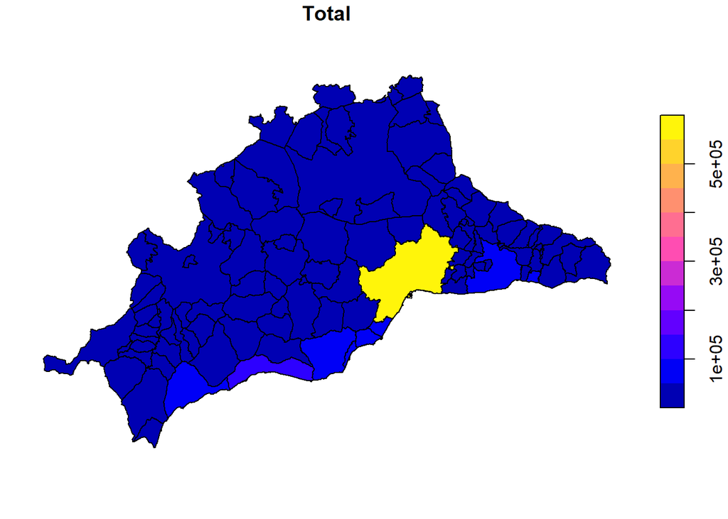

```r
# Creating codigo_ine field
poblacion_dt$codigo_ine <- substring(poblacion_dt$Municipios, 1, 5)
municipios_sf$codigo_ine <- substring(municipios_sf$NATCODE, 7, 11)

# Adding poblacion_dt fields to municipios by codigo_ine
municipios_sf <- merge(municipios_sf,
                      poblacion_dt,
                      by = 'codigo_ine',
                      all.x = TRUE)

# Plotting total population
plot(municipios_sf["Total"])
```

### 4.2. Red de carreteras

Vamos a usar el programa osm2po para generar un fichero sql con la sentencia para subir la red de carreteras que hemos descargado a nuestra base de datos PostGIS. Cuando aparezca el siguiente mensaje en la consola puedes parar la ejecución presionando el icono Stop de la consola.

INFO Services started. Waiting for requests at

http://localhost:8888/Osm2poService En ese momento y se habrá generado el fichero sp_2po_4pgr.sql

```r
# Creating road network SQL file
osm2po_command <- paste0('
cd modul12/ejercicio_02_red_transporte/software/osm2po-5.1.0
java -Xmx1g -jar osm2po-core-5.1.0-signed.jar prefix=sp "', input_path_02, 'carreteras_osm/spain-latest.osm.pbf"
yes
')
system("cmd.exe", input = osm2po_command)
```

## 5. Subir las capas a la la base de datos

### 5.1. Municipios

Comprobamos si la topología es correcta con la función st_is_valid.

```r
# Checking topology
topo_check <- sf::st_is_valid(municipios_sf)

# Percentage of elements with valid topology
topo_perc_ok <- length(subset(topo_check, topo_check == TRUE)) * 100 / nrow(municipios_sf)

# Number of elements with invalid topology
topo_number_ko <- length(subset(topo_check, topo_check == FALSE))

# id of elements with invalid topology
topo_elements_not_ok <- subset(topo_check, topo_check == FALSE)

# Returns
topo_results <- c("topo_perc_ok" = topo_perc_ok,
                    "topo_number_ko" = topo_number_ko,
                    "topo_elements_not_ok" = topo_elements_not_ok)
topo_results
```

```
##   topo_perc_ok topo_number_ko
##            100              0
```

Subimos la capa a PostGIS. Para que no haya problemas con los nombres de las columnas cuando hagamos las consultas, antes de subir la capa convertimos todos los nombres a minúsculas.

```r
# Setting column names to lower case
colnames(municipios_sf) <- tolower(colnames(municipios_sf))

# Writing municipios in PostGIS table
sf::st_write(dsn = db_conn,
           obj = municipios_sf,
           layer = "municipios_malaga",
           layer_options = c("OVERWRITE=yes"))

# Setting SRID
srid_query <- "
SELECT UpdateGeometrySRID('municipios_malaga','geometry',4326);
"
dbExecute(db_conn, srid_query)
```

```
## [1] -1
```

Creamos una capa con los centroides del municipio (en realidad punto similar al centroide que cae dentro del polígono municipal correspondiente).

Esta operación la realizamos directamente en la base de datos, utilizando la función ST_PointOnSurface sobre el campo geometry, que es el que almacena la información espacial.

```r
# Creating a point layer
# ST_PointOnSurface Returns a POINT guaranteed to lie on the surface
# https://postgis.net/docs/ST_PointOnSurface.html

centroids_query <- paste0("
DROP TABLE IF EXISTS municipios_malaga_point;

CREATE TABLE municipios_malaga_point AS
  SELECT codigo_ine,
          inspireid,
          country,
          nameunit,
          codnut1,
          codnut2,
          codnut3,
          total,
          hombres,
          mujeres,
          ST_PointOnSurface(geometry) as geometry
  FROM municipios_malaga;
  ")
dbExecute(db_conn, centroids_query)
```

```
## [1] 103
```

```r
# Setting SRID
srid_query <- "
SELECT UpdateGeometrySRID('municipios_malaga_point','geometry',4326);
"
dbExecute(db_conn, srid_query)
```

```
## [1] -1
```

## 5.2. Red de carreteras

Subimos la red de carreteras a PostGIS para poder crear una red de transporte a partir del fichero sp_2po_4pgr.sql generado en el paso 4.2. Para ellos ejecutamos psql desde R usando la función shell. Como la function shell no functiona diretamente desde R en mi caso, ejecutamos este comando directamente en la consola, para lo que hay que seguir estos pasos (con Windows):

1. Ve al menú de inicio de Windows y busca el programa ’Símbolo del sistema", o bien en el buscador de aplicaciones de Windows pon cmd (esto es lo mismo para todos los idiomas). Con doble click se abre una ventana con fondo negro y letras blancas, que es la consola
2. Copia y pega el comando que está dentro de la función shell, es decir, en el caso del html del ejercicio 2 esto es lo que hay que copiar y pegar en la consola: psql -U postgres -d postgis_db –host localhost –port 5432 -q -f “C:/Users/1/Desktop/modulo12/ejercicio_02_red_transporte/software/osm2po-5.1.0/sp/sp_2po_4pgr.sql”

```r
start <- Sys.time()

# Uploading sql file to PostGIS

# IMPORTANT: Replace the file path by your own path to sp_2po_4pgr.sql

shell('psql -U postgres -d postgis_db --host localhost --port 5432 -q -f "C:/Users/1/Desktop/modulo12/ejercicio_02_red_transporte/software/osm2po-5.1.0/sp/sp_2po_4pgr.sql"')

end <- Sys.time()

end - start
```

```r
# Creating bbox_malaga table
query_bbox <- "
DROP TABLE IF EXISTS bbox_malaga;

CREATE TABLE bbox_malaga AS
  SELECT ST_SetSRID(ST_Extent(ST_Buffer(geometry, 0.1)),4326) as bextent
  FROM municipios_malaga;
"
dbExecute(db_conn, query_bbox)
```

```
## [1] 1
```

```r
# Creating carreteras_malaga table
query_carreteras <- "
DROP TABLE IF EXISTS carreteras_malaga;

CREATE TABLE carreteras_malaga AS (
SELECT
  id,
  osm_id,
  osm_name,
  source,
  target,
  km,
  kmh,
  cost,
  reverse_cost,
  x1,
  y1,
  x2,
  y2,
  geom_way
FROM sp_2po_4pgr
WHERE ST_INTERSECTS(geom_way,
                    (SELECT bextent
                            FROM bbox_malaga))
);
"

dbExecute(db_conn, query_carreteras)
```

```
## [1] 136016
```

El siguiente paso es crear la topología de la red, para lo que necesitamos crear la tabla de vértices únicos (a partir de los campos source y target).

```r
# If the road network table already has source and target fields
# with unique vertex identifiers assigned to the corresponding edges,
# then we only need to create the vertices table, which should be fast (less than 1 minute)

# Creating vertices table
# https://docs.pgrouting.org/2.6/en/pgr_createVerticesTable.html
create_vertices_table_query <- "
SELECT  pgr_createVerticesTable('carreteras_malaga',
                                  the_geom:='geom_way',
                                  source:='source',
                                  target:='target'
                                );"
dbGetQuery(db_conn, create_vertices_table_query)
```

```
##   pgr_createverticestable
## 1                      OK
```

Antes de seguir, es conveniente analizar la topología creada.

```r
# Analysing the graph
# https://docs.pgrouting.org/2.6/en/pgr_analyzeGraph.html#pgr-analyze-graph

analyze_graph_query <- "
SELECT  pgr_analyzeGraph('carreteras_malaga',
                          0.001,source:='source',
                          id:='id',target:='target',
                          the_geom:='geom_way'
                        );"

dbGetQuery(db_conn, analyze_graph_query)
```

```
##   pgr_analyzegraph
## 1               OK
```

## 6. Conectar los centroides de los municipios con la red de transporte

Seleccionamos el nodo de de la red de carreteras que es más cercano al centroide de cada municipio. Este nodo será el verdadero punto de origen y destino en los cálculos.

```r
nearest_vertex_query <- "
DROP TABLE IF EXISTS municipio_nearest_vertex;

CREATE TABLE municipio_nearest_vertex AS
  SELECT munis.codigo_ine,
         distance,
         ver_id
        FROM municipios_malaga_point munis
        JOIN LATERAL (
            SELECT
            m.codigo_ine,
            st_distance(ST_Transform(m.geometry, 25830),ST_Transform(v.the_geom, 25830)) AS distance,
            v.id as ver_id
            FROM municipios_malaga_point m, carreteras_malaga_vertices_pgr v
            WHERE codigo_ine = munis.codigo_ine
            ORDER BY m.geometry <-> v.the_geom
            limit 1
        ) p on true
  ORDER BY munis.codigo_ine;
"
dbExecute(db_conn, nearest_vertex_query)
```

```
## [1] 103
```

## 7. Consultar rutas óptimas entre municipios por la red de transporte

Matriz de distancias óptimas por la red de transporte

### 7.1. Calculamos la matriz de distancias entre los 5 municipios más poblados de Malaga (todos contra todos) utilizando la función pgr_dijkstraCostMatrix.

```r
# Step 1. Getting the 5th most populated municipalities' codigo_ine in Malaga
pop_query <- "
SELECT codigo_ine,
        total
FROM municipios_malaga_point
WHERE total IS NOT NULL
ORDER BY total DESC
LIMIT 5;
"
pop <- data.table(dbGetQuery(db_conn, pop_query))
pop
```

```
##    codigo_ine  total
## 1:      29067 574654
## 2:      29069 143386
## 3:      29070  82742
## 4:      29094  81643
## 5:      29054  80309
```

```r
codigo_ine_pop <- data.table(dbGetQuery(db_conn, pop_query))

# Steps 1 & 2. Getting the corresponding nearest vertices
vertex_query <- "
SELECT codigo_ine,
       ver_id
FROM municipio_nearest_vertex
WHERE codigo_ine IN (SELECT codigo_ine
                     FROM municipios_malaga_point
                     WHERE total IS NOT NULL
                     ORDER BY total DESC
                     LIMIT 5);
"
vertex_selection <- data.table(dbGetQuery(db_conn, vertex_query))

# Steps 1 to 3. Getting Dijkstra cost matrix
# https://docs.pgrouting.org/latest/en/pgr_dijkstraCostMatrix.html#pgr-dijkstracostmatrix
dijkstra_route_query <- "
SELECT * FROM pgr_dijkstraCostMatrix(
                  'SELECT id,
                          source,
                          target,
                          km * 1000 as cost,
                          km * 1000 as reverse_cost
                    FROM carreteras_malaga',
                  (SELECT array_agg(id)
                    FROM carreteras_malaga_vertices_pgr
                    WHERE id IN
                               (SELECT ver_id
                                FROM municipio_nearest_vertex
                                WHERE codigo_ine IN (SELECT  codigo_ine
                                                     FROM municipios_malaga_point
                                                     WHERE total IS NOT NULL
                                                     ORDER BY total DESC
                                                     LIMIT 5)
                                )
                    ),
                  directed := false
                );
"
dijkstra_route <- data.table(dbGetQuery(db_conn, dijkstra_route_query))

dijkstra_route
```

```
##     start_vid end_vid  agg_cost
##  1:    460539  622689 62526.477
##  2:    460539  643099 34759.638
##  3:    460539  751466 21683.058
##  4:    460539 2187079  8075.458
##  5:    622689  460539 62526.477
##  6:    622689  643099 39306.159
##  7:    622689  751466 83916.133
##  8:    622689 2187079 70221.240
##  9:    643099  460539 34759.638
## 10:    643099  622689 39306.159
## 11:    643099  751466 56149.294
## 12:    643099 2187079 42367.897
## 13:    751466  460539 21683.058
## 14:    751466  622689 83916.133
## 15:    751466  643099 56149.294
## 16:    751466 2187079 18106.460
## 17:   2187079  460539  8075.458
## 18:   2187079  622689 70221.240
## 19:   2187079  643099 42367.897
## 20:   2187079  751466 18106.460
```

```r
# Adding origin codigo_ine to the result
dijkstra_route <- merge(x = dijkstra_route,
                        y = vertex_selection,
                        by.x = 'start_vid',
                        by.y = 'ver_id')
colnames(dijkstra_route) <- c('star_vid', 'end_vid', 'agg_cost', 'codigo_origen')

# Adding destination codigo_ine to the result
dijkstra_route <- merge(x = dijkstra_route,
                        y = vertex_selection,
                        by.x = 'end_vid',
                        by.y = 'ver_id')
colnames(dijkstra_route) <- c('end_vid', 'start_vid', 'agg_cost', 'codigo_origen', 'codigo_destino')
# The first field is the one in by.x

# View results
dijkstra_route
```

```
##     end_vid start_vid  agg_cost codigo_origen codigo_destino
##  1:  460539    622689 62526.477         29094          29054
##  2:  460539    643099 34759.638         29067          29054
##  3:  460539    751466 21683.058         29069          29054
##  4:  460539   2187079  8075.458         29070          29054
##  5:  622689    460539 62526.477         29054          29094
##  6:  622689    643099 39306.159         29067          29094
##  7:  622689    751466 83916.133         29069          29094
##  8:  622689   2187079 70221.240         29070          29094
##  9:  643099    460539 34759.638         29054          29067
## 10:  643099    622689 39306.159         29094          29067
## 11:  643099    751466 56149.294         29069          29067
## 12:  643099   2187079 42367.897         29070          29067
## 13:  751466    460539 21683.058         29054          29069
## 14:  751466    622689 83916.133         29094          29069
## 15:  751466    643099 56149.294         29067          29069
## 16:  751466   2187079 18106.460         29070          29069
## 17: 2187079    460539  8075.458         29054          29070
## 18: 2187079    622689 70221.240         29094          29070
## 19: 2187079    643099 42367.897         29067          29070
## 20: 2187079    751466 18106.460         29069          29070
```

### 7.2. Calculamos la distansia entre Malaga y Marbella

```r
# Shortest route between two points

shortest_route_query <- "SELECT * FROM pgr_dijkstra(
                               'SELECT id,
                                      source,
                                      target,
                                      km * 1000 as cost,
                                      km * 1000 as reverse_cost
                                      FROM carreteras_malaga',
                                (SELECT ver_id
                                      FROM municipio_nearest_vertex
                                      WHERE codigo_ine::int = 29067),
                                (SELECT ver_id
                                      FROM municipio_nearest_vertex
                                      WHERE codigo_ine::int = 29069)
                                          );"
shortest_route <- data.table(dbGetQuery(db_conn, shortest_route_query))

shortest_route
```

```
##      seq path_seq    node    edge     cost   agg_cost
##   1:   1        1  643099 2770195  43.9748     0.0000
##   2:   2        2 2107945 2770196  37.4904    43.9748
##   3:   3        3  642958  838487 123.3725    81.4652
##   4:   4        4  642959 1665180  14.0697   204.8377
##   5:   5        5 1287868 2992916  22.2748   218.9074
##  ---
## 359: 359      359  751459  979152 110.7827 54998.0145
## 360: 360      360  751451  979146 135.6442 55108.7972
## 361: 361      361  751452  979156 197.3108 55244.4414
## 362: 362      362 2249465  979157 707.5416 55441.7522
## 363: 363      363  751466      -1   0.0000 56149.2938
```

### 7.3. Calculamos los potenciales para tres municipios - Malaga, Marbella y Fuengirola

```r
camino_query<-"SELECT * FROM pgr_dijkstra(
                               'SELECT id,
                                      source,
                                      target,
                                      km * 1000 as cost,
                                      km * 1000 as reverse_cost
                                      FROM carreteras_malaga',
                                array(SELECT ver_id
                                      FROM municipio_nearest_vertex
                                      WHERE codigo_ine::int IN (29067,29069, 29070)),
                                array(SELECT ver_id
                                      FROM municipio_nearest_vertex
                                      WHERE codigo_ine IN (SELECT  codigo_ine
                                                     FROM municipios_malaga_point
                                                     ))
)

                                     WHERE edge=-1;"
camino<-data.table(dbGetQuery(db_conn, camino_query))
camino <-camino[,c(3,4,8)]
camino
```

```
##      start_vid end_vid  agg_cost
##   1:    643099    5570 126749.38
##   2:    643099    6178  53971.72
##   3:    643099   19742 109410.86
##   4:    643099   93846  54593.38
##   5:    643099  170032 114116.56
##  ---
## 287:   2187079 2266162  25556.54
## 288:   2187079 2267940  18859.04
## 289:   2187079 2273103  71351.77
## 290:   2187079 2280029  50691.58
## 291:   2187079 2471028  77108.71
```

```r
vertex_query <- "
SELECT codigo_ine,
       ver_id
FROM municipio_nearest_vertex"
vertex<- data.table(dbGetQuery(db_conn, vertex_query))
vertex
```

```
##      codigo_ine  ver_id
##   1:      29001 1953926
##   2:      29002 1220552
##   3:      29003 1210497
##   4:      29004  186680
##   5:      29005  572549
##  ---
##  99:      29100  812042
## 100:      29901 1310004
## 101:      29902  580780
## 102:      29903 1553677
## 103:      29904  705607
```

```r
# Adding origin codigo_ine to the result
camino <- merge(x = camino,
                        y = vertex,
                        by.x = 'start_vid',
                        by.y = 'ver_id')

colnames(camino) <- c('star_vid', 'end_vid', 'agg_cost', 'codigo_origen')
# Adding destination codigo_ine to the result
camino <- merge(x = camino,
                        y = vertex,
                        by.x = 'end_vid',
                        by.y = 'ver_id')
colnames(camino) <- c('end_vid', 'start_vid', 'agg_cost', 'codigo_origen', 'codigo_destino')

# View results
camino <- camino[,c(3,4,5)]
camino
```

```
##       agg_cost codigo_origen codigo_destino
##   1: 126749.38         29067          29056
##   2:  72652.44         29069          29056
##   3:  89114.88         29070          29056
##   4:  53971.72         29067          29016
##   5:  98152.81         29069          29016
##  ---
## 287:  34229.14         29069          29051
## 288:  50691.58         29070          29051
## 289:  86011.65         29067          29010
## 290:  93719.21         29069          29010
## 291:  77108.71         29070          29010
```

```r
camino_poblacion<-merge(x=camino,
                 y=poblacion_dt,
                 by.x = 'codigo_destino',
                        by.y = 'codigo_ine')
camino_poblacion<-camino_poblacion[,c(1,2,3,7)]
camino_poblacion
```

```
##      codigo_destino  agg_cost codigo_origen Total
##   1:          29001  66410.61         29067  5372
##   2:          29001 115405.94         29069  5372
##   3:          29001  98795.45         29070  5372
##   4:          29002  57160.24         29067  2230
##   5:          29002 101770.22         29069  2230
##  ---
## 287:          29903  85091.90         29069   593
## 288:          29903  91818.15         29070   593
## 289:          29904  85005.49         29067   477
## 290:          29904  81391.04         29069   477
## 291:          29904  68306.08         29070   477
```

```r
camino_poblacion<-data.frame(camino_poblacion)
malaga<-camino_poblacion[which(camino_poblacion$codigo_origen=='29067'),]
potencial_malaga<-sum(malaga$Total/malaga$agg_cost)
potencial_malaga
```

```
## [1] 24.95941
```

```r
marbella<-camino_poblacion[which(camino_poblacion$codigo_origen=='29069'),]
potencial_marbella<-sum(marbella$Total/marbella$agg_cost)
potencial_marbella
```

```
## [1] 32.87216
```

```r
fuengirola<-camino_poblacion[which(camino_poblacion$codigo_origen=='29070'),]
potencial_fuengirola<-sum(fuengirola$Total/fuengirola$agg_cost)
potencial_fuengirola
```

```
## [1] 51.43081
```

## 8. Desconexión de la base de datos

```r
# Disconnecting from database
dbDisconnect(db_conn)
```

```
## [1] TRUE
```